# Titre : IRIS : Deep Learning

# Introduction :

La reconnaissance de l'iris est un domaine crucial en informatique visuelle et en sécurité biométrique. Ce TP vise à explorer l'utilisation de techniques de Deep Learning pour détecter et reconnaître l'iris à partir d'images.

### Objectifs

- Comprendre les principes de base de la détection d'iris.
- Mettre en œuvre un modèle de Deep Learning pour la détection d'iris.
- Évaluer les performances du modèle sur un jeu de données spécifique.

### Conclusion

- Récapitulation des résultats obtenus.
- Discussion sur les limitations du modèle et des améliorations potentielles.
- Importance et applications potentielles de la détection d'iris basée sur le Deep Learning.

# 1- Importation des bibliothèques :

```python
import numpy as np  # Importe la bibliothèque NumPy sous l'alias "np" pour effectuer des opérations numériques.
import pandas as pd  # Importe la bibliothèque Pandas sous l'alias "pd" pour la manipulation de données en tableaux.
import matplotlib.pyplot as plt  # Importe la bibliothèque Matplotlib pour créer des graphiques.
import os  # Importe la bibliothèque "os" pour interagir avec le système de fichiers de l'ordinateur.
import seaborn as sns  # Importe la bibliothèque Seaborn pour la visualisation de données avancées.
import plotly.express as px  # Importe la bibliothèque Plotly Express pour créer des visualisations interactives.
import warnings

# Ignore les avertissements
warnings.filterwarnings("ignore")  # Ignorer les avertissements émis par le programme

# Import des bibliothèques pour le traitement d'image et le machine learning
import cv2 as cv
from sklearn.model_selection import train_test_split
from tensorflow.keras.layers import Input, Conv2D, MaxPooling2D, Flatten, Dense, Dropout, BatchNormalization, Activation, Normalization
from tensorflow.keras import Sequential
from sklearn.preprocessing import LabelEncoder
from tensorflow.keras.models import Model
```

```python
# Chemin du répertoire racine des images
path = './MMU-Iris-Database'
# Définissez les dimensions de l'image et d'autres paramètres
img_width, img_height = 150, 150

# Liste des côtés (right/left)
LeftImages = [] # Liste pour stocker les chemins des images de l'iris gauche
RightImages = [] # Liste pour stocker les chemins des images de l'iris droite
labels_person = [] # Liste pour stocker l'id de chaque personne
# Parcours des fichiers et sous-répertoires du répertoire principal
# Boucle sur les fichiers BMP dans le répertoire
for file in os.listdir(path):
    p = os.path.join('./MMU-Iris-Database/',file) # Chemin du répertoire de l'individu

# Chemins vers les répertoires "left" et "right" contenant les images
    pathRight = os.path.join(os.path.join('./MMU-Iris-Database/',file),'/right')

# Parcours des fichiers dans le répertoire "left"
    for imag in os.listdir(os.path.join('./MMU-Iris-Database/',file)+'/left'):
        if imag != "Thumbs.db": # Exclure les fichiers Thumbs.db s'ils existent
            img = cv.imread(f"{p}/left/{imag}", cv.IMREAD_GRAYSCALE)
            img = cv.resize(img, (img_width, img_height))
            LeftImages.append(img) # Ajouter le chemin de l'image gauche
            labels_person.append(int(file))
# Parcours des fichiers dans le répertoire "right"
    for imag in os.listdir(os.path.join('./MMU-Iris-Database/',file)+'/right'):
        if imag != "Thumbs.db": # Exclure les fichiers Thumbs.db s'ils existent
            img = cv.imread(f"{p}/right/{imag}", cv.IMREAD_GRAYSCALE)
            img = cv.resize(img, (img_width, img_height))
            RightImages.append(img) # Ajouter le chemin de l'image droite
            labels_person.append(int(file))
# Fin du traitement de l'image

TrainImages = [] # Liste pour les images d'entraînement
TestImages = []# Liste pour les images de test

X = LeftImages + RightImages
```

```python
# Afficher le nombre d'images pour chaque côté de l'iris
print(f"Nombre d'images pour l'œil gauche = {len(LeftImages)}")
print(f"Nombre d'images pour l'œil droit = {len(RightImages)}")
```

```
Nombre d'images pour l'œil gauche = 225
Nombre d'images pour l'œil droit = 225
```

```python
print(f"Nombre d'images = {len(X)}")
```

```
Nombre d'images = 450
```

```python
NUM_CLASSES = max(labels_person)+1
print(f"Nombre de personne : {len(set(labels_person))}")
```

```
Nombre de personne : 45
```

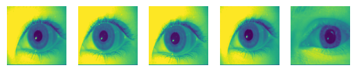

```python
# Import de la bibliothèque Matplotlib pour créer des graphiques
import matplotlib.pyplot as plt
# Définition d'une fonction pour afficher des images
def display_images(images):
    for i, img in enumerate(images):
        # Configuration des sous-graphiques pour afficher les images
        plt.subplot(1, len(images), i+1)
        plt.imshow(img)  # Affiche une image
        plt.axis('off')  # Désactive les axes
    plt.show()  # Affiche les images à l'écran

# Display images
display_images(X[1:6])
```

```python
def prepare_targets(y_train, y_test):
    # Crée une instance de LabelEncoder
    le = LabelEncoder()
    # Fait correspondre les étiquettes uniques des données d'entraînement à des entiers et ajuste l'encodeur
    le.fit(y_train)
    # Transforme les étiquettes d'entraînement en utilisant l'encodeur ajusté pour les encoder en entiers
    y_train_enc = le.transform(y_train)
    # Transforme les étiquettes de test en utilisant le même encodeur pour assurer la cohérence
    y_test_enc = le.transform(y_test)
    # Renvoie les étiquettes encodées pour l'entraînement et le test
    return y_train_enc, y_test_enc
```

```python
from tensorflow.keras.utils import to_categorical

max_pixel_value = 255.0  # La valeur maximale d'un pixel dans une image (échelle de gris)
X = np.array(X)  # Convertit X en un tableau NumPy
X = X.astype('float32') / max_pixel_value  # Normalise les valeurs des pixels en les divisant par la valeur maximale
```

```python
# Divise les données X et labels_person en ensembles d'entraînement et de test
# avec une proportion de test (test_size=0.4)
# et utilise une graine (seed) fixe pour garantir la reproductibilité des résultats (random_state=42)
X_train, X_test, y_train, y_test = train_test_split(X, labels_person, test_size=0.4, random_state=42)
```

```python
from tensorflow.keras.utils import to_categorical
# Convertit les étiquettes (labels) d'entraînement en encodage one-hot
# Le paramètre max(labels_person) + 1 détermine le nombre de classes pour l'encodage one-hot
train_labels = to_categorical(y_train, max(labels_person) + 1)

# Convertit les étiquettes (labels) de test en encodage one-hot
# max(labels_person) + 1 est utilisé pour s'assurer que toutes les classes sont incluses dans l'encodage
test_labels = to_categorical(y_test, max(labels_person) + 1)
```

# 2. Convolutional Neural Network (CNN or ConvNet)

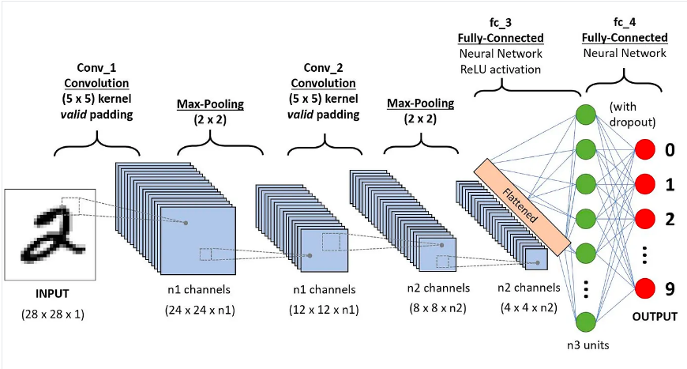

```python
# Ajoute une dimension supplémentaire à X_train à la fin (axis=-1)
# Cela est souvent utilisé pour spécifier explicitement le nombre de canaux pour les images (ici, 1 canal pour les images en noir et blanc)
X_train = np.expand_dims(X_train, axis=-1)

# Ajoute une dimension supplémentaire à X_test à la fin (axis=-1)
# De la même manière que pour X_train, cela permet de spécifier le nombre de canaux pour les images de test
X_test = np.expand_dims(X_test, axis=-1)
```

```python
from tensorflow.keras.optimizers import Adam  # Importation de l'optimiseur Adam
from tensorflow.keras.callbacks import EarlyStopping  # Importation de la fonction de callback EarlyStopping

# Paramètres
INPUT_SHAPE = (img_width, img_height, 1)  # Dimensions de l'entrée pour une image en niveaux de gris

FILTER1_SIZE = 32  # Taille du premier filtre
FILTER2_SIZE = 64  # Taille du deuxième filtre
FILTER_SHAPE = (3, 3)  # Forme des filtres (3x3)
POOL_SHAPE = (2, 2)  # Forme du pooling (2x2)
FULLY_CONNECT_NUM = 64  # Nombre d'unités pour les couches entièrement connectées
NUM_CLASSES = max(labels_person) + 1  # Nombre de classes pour la prédiction

# Définition du modèle CNN
model_cnn = Sequential()  # Création d'un modèle séquentiel

# Ajout des couches de convolution et de pooling
model_cnn.add(Conv2D(32, (3, 3), activation='relu', input_shape=INPUT_SHAPE))  # Couche de convolution avec activation ReLU
model_cnn.add(MaxPooling2D((2, 2)))  # Couche de pooling
model_cnn.add(Conv2D(64, (3, 3), activation='relu'))  # Autre couche de convolution avec activation ReLU
model_cnn.add(MaxPooling2D((2, 2)))  # Autre couche de pooling
model_cnn.add(Conv2D(128, (3, 3), activation='relu'))  # Autre couche de convolution avec activation ReLU
model_cnn.add(MaxPooling2D((2, 2)))  # Autre couche de pooling

# Ajout de couches entièrement connectées
model_cnn.add(Flatten())  # Aplatir les données en un vecteur pour les couches entièrement connectées
model_cnn.add(Dense(128, activation='relu'))  # Couche entièrement connectée avec activation ReLU
model_cnn.add(Dense(NUM_CLASSES, activation='softmax'))  # Couche de sortie avec activation softmax pour la classification multi-classes

model_cnn.compile(optimizer='adam', loss='categorical_crossentropy', metrics=['accuracy'])  # Compilation du modèle avec l'optimiseur Adam et la fonction de perte 'categorical_crossentropy'
```

## Paramétrage:

Voici les paramètres pour la construction de notre modèle CNN, comme la taille des filtres, la forme des couches de pooling, etc.

Construction du modèle CNN:

- utilisation des couches Conv2D pour la convolution avec différentes tailles de filtres.
- MaxPooling2D est utilisé pour réduire la dimensionnalité spatiale.
- Flatten convertit les matrices 2D des couches convolutives en un vecteur 1D.
- Des couches Dense sont ajoutées pour la classification.

Compilation du modèle:

- utilisation l'optimiseur Adam et la perte categorical_crossentropy, ce qui est approprié pour une tâche de classification multiclasse.

Pour améliorer les performances de votre modèle et éviter le surajustement ou le sous-ajustement, considérez les points suivants :

- Validation Croisée : Division vos données en ensembles de formation et de test (et éventuellement de validation) pour évaluer correctement les performances du modèle.
- Early Stopping : Utilisation EarlyStopping pour arrêter l'entraînement lorsque la performance sur l'ensemble de validation commence à se dégrader. Cela aide à prévenir le surajustement.
- Régularisation : Ajout de la régularisation, comme la régularisation L1/L2 ou la méthode Dropout, pour contrôler la complexité du modèle.
- Ajustement des Hyperparamètres : Expériment avec différents nombres de couches, tailles de filtres, et autres hyperparamètres pour trouver la configuration optimale.

```python
# Entraîner le modèle
model_cnn_history = model_cnn.fit(X_train, train_labels, epochs=10, validation_data=(X_test, test_labels))
```

[figure not shown]

```python
### Tracer les courbes de perte d'entraînement et de validation
plt.figure(figsize=(12, 5))  # Définit la taille de la figure

# Tracer les valeurs de précision d'entraînement et de validation
plt.subplot(1, 2, 1)  # Créer le premier sous-graphique
plt.plot(model_cnn_history.history['accuracy'])  # Tracer la précision d'entraînement
plt.plot(model_cnn_history.history['val_accuracy'])  # Tracer la précision de validation
plt.title('Précision du modèle')  # Titre du graphique
plt.xlabel('Époque')  # Étiquette de l'axe des abscisses
plt.ylabel('Précision')  # Étiquette de l'axe des ordonnées
plt.legend(['Entraînement', 'Validation'], loc='upper left')  # Légende du graphique

# Tracer les valeurs de perte d'entraînement et de validation
plt.subplot(1, 2, 2)  # Créer le deuxième sous-graphique
plt.plot(model_cnn_history.history['loss'])  # Tracer la perte d'entraînement
plt.plot(model_cnn_history.history['val_loss'])  # Tracer la perte de validation
plt.title('Perte du modèle')  # Titre du graphique
plt.xlabel('Époque')  # Étiquette de l'axe des abscisses
plt.ylabel('Perte')  # Étiquette de l'axe des ordonnées
plt.legend(['Entraînement', 'Validation'], loc='upper left')  # Légende du graphique

plt.show()  # Afficher le graphique
```

# 3. VGG16

##### Définition

VGG16 est un modèle de réseau de neurones convolutifs (CNN) développé par Karen Simonyan et Andrew Zisserman de l'Université d'Oxford, présenté dans leur article de 2014 intitulé "Very Deep Convolutional Networks for Large-Scale Image Recognition". Le modèle a été nommé VGG en l'honneur du Visual Graphics Group de l'Université d'Oxford et "16" indique qu'il a 16 couches qui ont des poids.

```python
# Charger le modèle VGG16 pré-entraîné sans les couches supérieures (entièrement connectées)
base_model = VGG16(weights='imagenet', include_top=False, input_shape=(150, 150, 3))

# Geler les poids des couches pré-entraînées
for layer in base_model.layers:
    layer.trainable = False

# Créer un nouveau modèle en ajoutant des couches supérieures personnalisées pour votre tâche de classification spécifique
model = Sequential()
model.add(Normalization())  # Normaliser les données en entrée
model.add(base_model)  # Ajouter les couches de base du modèle VGG16
model.add(Flatten())  # Aplatir les données en un vecteur pour les couches entièrement connectées
model.add(Dense(256, activation='relu'))  # Ajouter une couche Dense avec une activation ReLU
model.add(Dropout(0.3))  # Ajouter une couche de Dropout pour régulariser le modèle
model.add(Dense(NUM_CLASSES, activation='softmax'))  # Ajuster le nombre d'unités en fonction de votre tâche de classification spécifique
```

```python
# Répéter les canaux des images d'entraînement pour correspondre aux exigences de l'entrée du modèle VGG16
train_images_vgg = np.repeat(X_train[..., np.newaxis], 3, -1)

# Répéter les canaux des images de test pour correspondre aux exigences de l'entrée du modèle VGG16
test_images_vgg = np.repeat(X_test[..., np.newaxis], 3, -1)
```

```python
# Compiler le modèle
model.compile(optimizer=Adam(), loss='categorical_crossentropy', metrics=['accuracy'])
```

```python
# Définition d'un callback EarlyStopping pour arrêter l'entraînement si la perte de validation ne s'améliore pas pendant un certain nombre d'époques
early_stopping = EarlyStopping(monitor='val_loss', patience=2, restore_best_weights=True)

# Entraîner le modèle
model_vgg16_history = model.fit(
    train_images_vgg, train_labels,  # Utilisation des images d'entraînement et des étiquettes correspondantes
    epochs=10,  # Nombre d'époques d'entraînement
    validation_data=(test_images_vgg, test_labels),  # Utilisation des images de test pour la validation
    callbacks=[early_stopping]  # Utilisation du callback EarlyStopping pour arrêter l'entraînement prématurément si nécessaire
)
```

[figure not shown]

```python
# Tracer les courbes de perte d'entraînement et de validation
plt.figure(figsize=(12, 5))  # Définit la taille de la figure

# Tracer les valeurs de précision d'entraînement et de validation
plt.subplot(1, 2, 1)  # Créer le premier sous-graphique
plt.plot(model_vgg16_history.history['accuracy'])  # Tracer la précision d'entraînement
plt.plot(model_vgg16_history.history['val_accuracy'])  # Tracer la précision de validation
plt.title('Précision du modèle')  # Titre du graphique
plt.xlabel('Époque')  # Étiquette de l'axe des abscisses
plt.ylabel('Précision')  # Étiquette de l'axe des ordonnées
plt.legend(['Entraînement', 'Validation'], loc='upper left')  # Légende du graphique

# Tracer les valeurs de perte d'entraînement et de validation
plt.subplot(1, 2, 2)  # Créer le deuxième sous-graphique
plt.plot(model_vgg16_history.history['loss'])  # Tracer la perte d'entraînement
plt.plot(model_vgg16_history.history['val_loss'])  # Tracer la perte de validation
plt.title('Perte du modèle')  # Titre du graphique
plt.xlabel('Époque')  # Étiquette de l'axe des abscisses
plt.ylabel('Perte')  # Étiquette de l'axe des ordonnées
plt.legend(['Entraînement', 'Validation'], loc='upper left')  # Légende du graphique

plt.show()  # Afficher le graphique
```

# 4. LSTM

##### Définition :

LSTM, qui signifie "Long Short-Term Memory", est un type de réseau de neurones récurrent (RNN) utilisé en apprentissage profond. Les LSTM sont particulièrement adaptés pour reconnaître, traiter et prédire des séquences de données avec des intervalles de temps de longueurs variables, comme c'est souvent le cas dans les séries temporelles, la parole, la reconnaissance de l'écriture manuscrite, et dans le traitement du langage naturel.

Un RNN, ou Réseau de Neurones Récurrent (Recurrent Neural Network en anglais), est une classe de réseaux de neurones artificiels où les connexions entre les nœuds forment une séquence dirigée le long d'une séquence temporelle

```python
from tensorflow.keras.layers import Input, LSTM, Dropout, Embedding, Dense, Flatten, Concatenate
```

```python
# Définir la forme d'entrée pour LSTM
input_shape = (150, 150)  # Forme de l'image

# Remodeler les images pour LSTM (3 canaux requis)
train_images_lstm = np.repeat(train_images[..., np.newaxis], 3, -1)
test_images_lstm = np.repeat(test_images[..., np.newaxis], 3, -1)

# Définir le modèle LSTM
image_input = Input(shape=input_shape)  # Entrée pour les images
x = LSTM(128)(image_input)  # Couche LSTM avec 128 unités

# Entrées auxiliaires pour les étiquettes (labels)
person_label_input = Input(shape=(1,))

# Couches d'incorporation (embedding) pour les étiquettes
person_embedding = Embedding(input_dim=NUM_CLASSES, output_dim=50)(person_label_input)

# Concaténation de la sortie de LSTM avec les incrustations d'étiquettes
x = Flatten()(x)

# Couches entièrement connectées pour la prédiction finale
x = Dense(128, activation='relu')(x)
output_person = Dense(1, activation='linear', name='output_person')(x)  # Activation linéaire pour une régression

# Définir le modèle avec des sorties multiples
model = Model(inputs=[image_input], outputs=[output_person])  # Modèle avec une entrée d'image et une sortie de prédiction de personne
```

```python
# Compiler le modèle
model.compile(optimizer='adam', loss='mse', metrics=['accuracy'])

# Entraîner le modèle LSTM
model_LSTM_history = model.fit(
    train_images, train_labels_person,  # Utilisation des images d'entraînement et des étiquettes correspondantes
    batch_size=batch_size,  # Taille du lot d'entraînement
    epochs=10,  # Nombre d'époques d'entraînement
    validation_data=(test_images, test_labels_person)  # Utilisation des images de test pour la validation
)
```

[figure not shown]

```python
# Tracer les courbes de perte d'entraînement et de validation
plt.figure(figsize=(12, 5))  # Définit la taille de la figure

# Tracer les valeurs de précision d'entraînement et de validation
plt.subplot(1, 2, 1)  # Créer le premier sous-graphique
plt.plot(model_LSTM_history.history['accuracy'])  # Tracer la précision d'entraînement
plt.plot(model_LSTM_history.history['val_accuracy'])  # Tracer la précision de validation
plt.title('Précision du modèle')  # Titre du graphique
plt.xlabel('Époque')  # Étiquette de l'axe des abscisses
plt.ylabel('Précision')  # Étiquette de l'axe des ordonnées
plt.legend(['Entraînement', 'Validation'], loc='upper left')  # Légende du graphique

# Tracer les valeurs de perte d'entraînement et de validation
plt.subplot(1, 2, 2)  # Créer le deuxième sous-graphique
plt.plot(model_LSTM_history.history['loss'])  # Tracer la perte d'entraînement
plt.plot(model_LSTM_history.history['val_loss'])  # Tracer la perte de validation
plt.title('Perte du modèle')  # Titre du graphique
plt.xlabel('Époque')  # Étiquette de l'axe des abscisses
plt.ylabel('Perte')  # Étiquette de l'axe des ordonnées
plt.legend(['Entraînement', 'Validation'], loc='upper left')  # Légende du graphique

plt.show()  # Afficher le graphique
```

### Matrice confusion

Considérons une situation binaire où les classes seraient :

- Classe positive : Iris identifié correctement
- Classe négative : Iris non identifié correctement

La matrice de confusion pour un modèle VGG16 dans ce contexte pourrait être représentée comme suit :

```
|               | Iris identifié correctement | Iris non identifié correctement |
|---------------|-----------------------------|---------------------------------|
| Iris          | Vrais Positifs (VP)         | Faux Négatifs (FN)              |
| Non-Iris      | Faux Positifs (FP)          | Vrais Négatifs (VN)             |
```

- **Vrais Positifs (VP)** : Nombre d'iris correctement identifiés par le modèle VGG16.
- **Faux Négatifs (FN)** : Nombre d'iris réels non identifiés correctement par le modèle.
- **Faux Positifs (FP)** : Nombre d'instances où le modèle a identifié à tort un iris alors qu'il n'était pas présent.
- **Vrais Négatifs (VN)** : Nombre d'instances correctement prédites comme étant non iris.

Cette matrice nous permettra de voir où notre modèle VGG16 se trompe le plus souvent : s'il identifie à tort des iris (FP) ou s'il manque d'identifier des iris réels (FN).

[figure not shown]

```python
from tensorflow.keras.utils import to_categorical
from sklearn.metrics import confusion_matrix

# Supposons que nous ayons des labels binaires ou multiclasse
# Pour cet exemple, je vais convertir les labels en format one-hot (adaptez selon vos besoins)
train_labels_person_one_hot = to_categorical(train_labels_person)
test_labels_person_one_hot = to_categorical(test_labels_person)

# Modifier les couches de sortie pour la classification
output_person = Dense(2, activation='softmax', name='output_person')(x)  # Utiliser softmax pour la classification multiclasse
# Répétez pour 'output_iris' si nécessaire

# Redéfinir le modèle avec les nouvelles sorties
model = Model(inputs=[base_model.input, person_label_input, iris_label_input], outputs=[output_person])  # Ajoutez output_iris si nécessaire

# Compiler le modèle pour la classification
model.compile(optimizer='adam', loss='categorical_crossentropy', metrics=['accuracy'])  # Utiliser categorical_crossentropy

# Entraîner le modèle (assurons que les labels sont en format approprié)
history = model.fit(
    [train_images, train_labels_person_one_hot, train_labels_iris],  # Assurons d'utiliser des labels one-hot
    [train_labels_person_one_hot, train_labels_iris],
    epochs=10,
    batch_size=32,
    validation_data=([test_images, test_labels_person_one_hot, test_labels_iris], [test_labels_person_one_hot, test_labels_iris])
)

# Prédire les classes sur l'ensemble de test
predicted_classes = model.predict([test_images, test_labels_person, test_labels_iris])
predicted_classes = np.argmax(predicted_classes, axis=1)  # Convertir les prédictions en labels de classe

# Calculer la matrice de confusion
conf_mat = confusion_matrix(np.argmax(test_labels_person_one_hot, axis=1), predicted_classes)

# Afficher la matrice de confusion
plt.figure(figsize=(15, 15))
sns.heatmap(conf_matrix, annot=True, cmap='Blues', fmt='g', square=True)
plt.title('Matrice de confusion VGG16')
plt.ylabel('Véritable étiquette')
plt.xlabel('Étiquette prédite')
plt.show()
```

# Conclusion :

Un TP (Travaux Pratiques) sur la détection de l'iris en utilisant des modèles de deep learning en vision par ordinateur peut offrir une expérience éducative précieuse pour plusieurs raisons :

En conclusion, un TP de détection d'iris en utilisant des modèles de deep learning en vision par ordinateur offre une opportunité d'acquérir des compétences pratiques en manipulation de données, en entraînement de modèles, en évaluation de performances, tout en explorant une application spécifique dans le domaine de la vision par ordinateur. Cette expérience leur permet de se familiariser avec les concepts clés du deep learning tout en abordant un problème concret et pertinent.